# employeesRF

Walter

March 15, 2020

This markdown document develops a decision tree to determine if an employee will Attrition, leave their job. The objective was to find the optimal value for the cost parameter in the decision tree function. I wanted to find how much to penalize false negatives (model predicts employee will stay when he/she actually quits), while still having a high specificity.

Sensitivity is defined as model correctly predicting an employee will quit when the employee actually did quit. Specificity is defined as model correctly predicting an employee will not quit when the employee actually did not quit. False negative means model predicts No for attrition when the employee actually quits.

load data

```r
employees=read.csv("CaseStudy2-data.csv")

library(randomForest)
library(caret)
library(C50)
library(gmodels)
library(dplyr)
```

```r
library(ggplot2)
library(tidyr)
```

Prepare train test split

```r
split=0.5
data=employees[,(names(employees)!="Over18")]
TrainObs = sample(seq(1,dim(data)[1]),round(split*dim(data)[1]),replace = FALSE)
train = data[TrainObs,]
test = data[-TrainObs,]
```

Create Tree

```r
tree=C5.0(x=train[,-3],y=train[,3])
```

This code chunk below that creates the initial cost matrix was adapted from Brett Lantz “Machine Learning with R Second Edition”.

```r
treePreds= predict(tree,test[,-3])
CrossTable(test$Attrition,treePreds,prop.chisq = FALSE, prop.c = FALSE, prop.r = FALSE,             dnn = c('actual attrition', 'predicted attrition'))
```

```
##
##
##    Cell Contents
## |-------------------------|
## |                       N |
## |         N / Table Total |
## |-------------------------|
##
##
## Total Observations in Table:  435
##
##
##                  | predicted attrition
## actual attrition |        No |       Yes | Row Total |
## -----------------|-----------|-----------|-----------|
##               No |       326 |        37 |       363 |
##                  |     0.749 |     0.085 |           |
## -----------------|-----------|-----------|-----------|
##              Yes |        46 |        26 |        72 |
##                  |     0.106 |     0.060 |           |
## -----------------|-----------|-----------|-----------|
##     Column Total |       372 |        63 |       435 |
## -----------------|-----------|-----------|-----------|
##
##
```

```r
matrix_dimensions <- list(c("No", "Yes"), c("No", "Yes"))
names(matrix_dimensions) <- c("predicted", "actual")
error_cost <- matrix(c(0, 1, 4, 0), nrow = 2,    dimnames = matrix_dimensions)
tree=C5.0(x=train[,-3],y=train[,3],costs = error_cost)
treePreds= predict(tree,test[,-3])
results=CrossTable(test$Attrition,treePreds,prop.chisq = FALSE, prop.c = FALSE, prop.r = FALSE,             dnn = c('actual attrition', 'predicted attrition'))
```

```
##
##
##    Cell Contents
## |-------------------------|
## |                       N |
## |         N / Table Total |
## |-------------------------|
##
##
## Total Observations in Table:  435
##
##
##                  | predicted attrition
## actual attrition |        No |       Yes | Row Total |
## -----------------|-----------|-----------|-----------|
##               No |       263 |       100 |       363 |
##                  |     0.605 |     0.230 |           |
## -----------------|-----------|-----------|-----------|
##              Yes |        25 |        47 |        72 |
##                  |     0.057 |     0.108 |           |
## -----------------|-----------|-----------|-----------|
##     Column Total |       288 |       147 |       435 |
## -----------------|-----------|-----------|-----------|
##
##
```

```r
"specificity"
```

```
## [1] "specificity"
```

```r
results$prop.row[1,1]
```

```
## [1] 0.7245179
```

```r
"sensitivity"
```

```
## [1] "sensitivity"
```

```r
results$prop.row[2,2]
```

```
## [1] 0.6527778
```

monte carlo Cross validation of tree with cost matrix with a false negative penalty cost = 4, Penalize a False negative harsher because our model had a very low sensitivity

```r
iterations=10
sensitivities=numeric(iterations)
specificity=numeric(iterations)

monteCarloTree=function(cost)
{sink("NUL")
for (i in 1:iterations)
{TrainObs = sample(seq(1,dim(data)[1]),round(split*dim(data)[1]),replace = FALSE)
train = data[TrainObs,]
test = data[-TrainObs,]
error_cost <- matrix(c(0, 1, cost, 0), nrow = 2,    dimnames = matrix_dimensions)
tree=C5.0(x=train[,-3],y=train[,3],costs = error_cost)
treePreds= predict(tree,test[,-3])
results=CrossTable(test$Attrition,treePreds,prop.chisq = FALSE, prop.c = FALSE, prop.r = FALSE,             dnn = c('actual attrition', 'predicted attrition'))
specificity[i]=results$prop.row[1,1]
sensitivities[i]=results$prop.row[2,2]
}
sink()
list(
  sensitivities=sensitivities,
  specificity=specificity
)
}
out=monteCarloTree(4)
sprintf(fmt="%10s%10f","Average Sensitvity",mean(out$sensitivities))
```

```
## [1] "Average Sensitvity  0.471193"
```

```r
sprintf(fmt="%10s%10f","Average Specificity",mean(out$specificity))
```

```
## [1] "Average Specificity  0.753489"
```

```r
costs=c(2,4,6,8,10)
costSens=matrix(nrow=length(costs),ncol=iterations)
costSpec=matrix(nrow=length(costs),ncol=iterations)

for(i in 1:length(costs))
  {out=monteCarloTree(costs[i])
costSens[i,]=out$sensitivities
costSpec[i,]=out$specificity}
```

Tidy the Sensitivity Specificity Dataframes

```r
costSens=cbind(costSens,costs)
costSpec=cbind(costSpec,costs)
costDf=as.data.frame(costSens) %>%
  gather("iteration","value",-costs) %>% select(costs,value) %>%
  mutate(metric="sensitivity")
costDf=  as.data.frame(costSpec) %>%
  gather("iteration","value",-costs)%>% select(costs,value) %>%
  mutate(metric="specificity") %>% rbind(costDf)
```

Plot the sensitivity and specificity of each cost parameter value

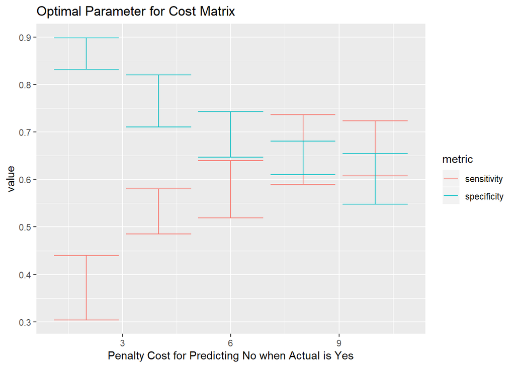

```r
ggplot(costDf) +
  stat_summary(aes(costs,value,color=metric),fun.data = function(x){data.frame(y=mean(x),ymin=mean(x)-sd(x),
ymax=mean(x)+sd(x))},
geom="errorbar")+xlab("Penalty Cost for Predicting No when Actual is Yes")+labs(title="Optimal Parameter for Cost Matrix")
```

It seems the best cost value for parameter is 8. Remake the tree with a cost matrix of 8 for false negatives for “Yes”

```r
split=0.5
data=employees[,(names(employees)!="Over18")]
TrainObs = sample(seq(1,dim(data)[1]),round(split*dim(data)[1]),replace = FALSE)
train = data[TrainObs,]
test = data[-TrainObs,]

#now its an 8
error_cost <- matrix(c(0, 1, 8, 0), nrow = 2,    dimnames = matrix_dimensions)
tree=C5.0(x=train[,-3],y=train[,3],costs = error_cost)
```

This is the decision tree with best parameter value for cost matrix

```r
summary(tree)
```

```
##
## Call:
## C5.0.default(x = train[, -3], y = train[, 3], costs = error_cost)
##
##
## C5.0 [Release 2.07 GPL Edition]      Mon Mar 16 13:02:29 2020
## -------------------------------
##
## Class specified by attribute `outcome'
##
## Read 435 cases (35 attributes) from undefined.data
## Read misclassification costs from undefined.costs
##
## Decision tree:
##
## MaritalStatus = Divorced:
## :...NumCompaniesWorked <= 6: No (79)
## :   NumCompaniesWorked > 6: Yes (8/6)
## MaritalStatus in {Married,Single}:
## :...OverTime = Yes:
##     :...JobSatisfaction <= 2: Yes (26/7)
##     :   JobSatisfaction > 2:
##     :   :...YearsAtCompany <= 2: Yes (16/7)
##     :       YearsAtCompany > 2:
##     :       :...Gender = Female: No (17)
##     :           Gender = Male: Yes (31/25)
##     OverTime = No:
##     :...TotalWorkingYears <= 2: Yes (15/8)
##         TotalWorkingYears > 2:
##         :...JobRole in {Human Resources,Manufacturing Director,
##             :           Research Director}: No (45)
##             JobRole in {Healthcare Representative,Laboratory Technician,
##             :           Manager,Research Scientist,Sales Executive,
##             :           Sales Representative}:
##             :...StockOptionLevel > 2: Yes (3/1)
##                 StockOptionLevel <= 2:
##                 :...JobInvolvement <= 2:
##                     :...ID <= 588: Yes (45/33)
##                     :   ID > 588: No (27)
##                     JobInvolvement > 2:
```

[output cut: 27 more lines]

```
##   59.31% TotalWorkingYears
##   55.86% JobRole
##   45.52% StockOptionLevel
##   44.83% JobInvolvement
##   28.28% YearsSinceLastPromotion
##   28.05% WorkLifeBalance
##   20.69% JobSatisfaction
##   20.00% NumCompaniesWorked
##   16.55% ID
##   14.71% YearsAtCompany
##   11.03% Gender
##    3.22% PerformanceRating
##
##
## Time: 0.0 secs
```